# CUBI advanced R bioinformatics course / 02

## Dispersion plots

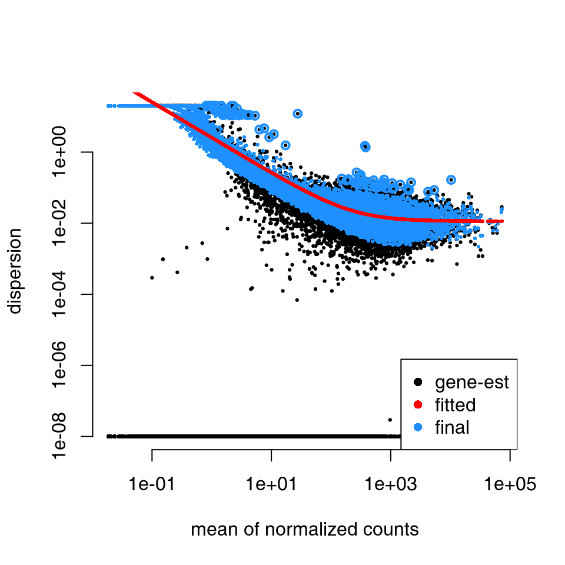

The plot shows a first estimate of dispersion (\(\alpha\) parameter) for each gene (black dots), then a fitted model for all genes (red line), and then a posterior estimation (called "shrinkage") of the per gene dispersion using bayesian statistics (blue dots). The plot below is typical.

## Getting the actual results

`results` pulls the result for the comparison defined by contrasts or by name (we will come back to that later).

```r
res <- results(ds, contrast=c("group", "A549.RSV", "A549.mock"))
head(res[ order(res$pvalue), ])
```

```
## log2 fold change (MLE): group A549.RSV vs A549.mock
## Wald test p-value: group A549.RSV vs A549.mock
## DataFrame with 6 rows and 6 columns
##                         baseMean   log2FoldChange              lfcSE
##                        <numeric>        <numeric>          <numeric>
## ENSG00000100342 754.285658130664 4.77976981916278  0.108320435461471
## ENSG00000117983 1794.92379023533 5.36336233524793  0.128481854411652
## ENSG00000170345 2277.13550786117 7.80742122155175  0.175633480565241
## ENSG00000187608  1315.4848259698 8.13076973690357  0.207804625255036
## ENSG00000170581 1198.57751465104 3.56476802391887 0.0976722835910521
## ENSG00000243649 1152.85077401289  5.4792308495698  0.153984485043631
##                             stat                pvalue                  padj
##                        <numeric>             <numeric>             <numeric>
## ENSG00000100342 44.1262057228613                     0                     0
## ENSG00000117983 41.7441230110508                     0                     0
## ENSG00000170345 44.4529209147661                     0                     0
## ENSG00000187608 39.1269911674236                     0                     0
## ENSG00000170581 36.4972323043488 1.22691393352563e-291 3.84907439225661e-288
## ENSG00000243649 35.5830059633428 2.56630291191146e-277 6.70917124604054e-274
```

## Understanding contrasts (demo)

groups A, B, C and D:

- \(A - B\) group A vs group B, group A in the nominator
- \((A - B) + (C - D)\) summed effects
- \((A - B) - (C - D)\) interaction

## Contrast specification in DESeq2

1. Nominator vs denominator (character vector with three elements), which is basically \(A - B\);
2. list of two vectors (all groups in nominator vs all groups in denominator);
3. numeric vector.

## Simple case: two groups

There are two options to proceed

- Fit with an intercept (omit the `0` in formula) and use the direct comparison (the `name` option to `results()`)
- Fit without an intercept (`~ 0 + group`) and define a contrast (the `contrast` option to `results()`)

## Simple case: two groups

Fit with an intercept. We are estimating two parameters: the average of the first group (the intercept) to which all the remaining are compared, and the relative differences between other groups and the first group. This gives us a direct comparison between the two groups.

```r
nhbe <- counts[, 1:6]
nhbe.cov <- covar[1:6, ]
ds.nhbe <- DESeqDataSetFromMatrix(nhbe, nhbe.cov, ~ group)
ds.nhbe <- DESeq(ds.nhbe)
resultsNames(ds.nhbe)
```

```
## [1] "Intercept"                    "group_NHBE.SC2V_vs_NHBE.mock"
```

```r
res1 <- results(ds.nhbe, name="group_NHBE.SC2V_vs_NHBE.mock")
```

## Simple case: two groups

Fit without an intercept. Here, we have averages for each group, which are by itself meaningless, as they show us only which genes are significantly larger than 0. Thus, we need to define the contrasts.

```r
ds.nhbe <- DESeqDataSetFromMatrix(nhbe, nhbe.cov, ~ 0 + group)
ds.nhbe <- DESeq(ds.nhbe)
resultsNames(ds.nhbe)
```

```
## [1] "groupNHBE.mock" "groupNHBE.SC2V"
```

```r
res2 <- results(ds.nhbe, contrast=c("group", "NHBE.SC2V", "NHBE.mock"))
```

## Simple case: two groups

Alternatively, we can define contrast with a numeric vector. The vector must have the same length as the output of `resultsNames`. Each coefficient returned by `resultsNames` will be multiplied by the respective value from the vector, so specifying `c(-1, 1)` is equivalent to the contrast `NHBE.SC2V-NHBE.mock`. Contrast value of `0` means that the given coefficient will not be taken into account *at all*!

```r
resultsNames(ds.nhbe)
```

```
## [1] "groupNHBE.mock" "groupNHBE.SC2V"
```

```r
res3 <- results(ds.nhbe, contrast=c(-1, 1))
identical(as.data.frame(res2), as.data.frame(res3))
```

```
## [1] TRUE
```

## Simple case: two groups

In the latter case, we first fit the group averages (instead of an intercept and a relative difference between two groups) and then define a *contrast* that specifies the difference between the groups. Are the results identical?

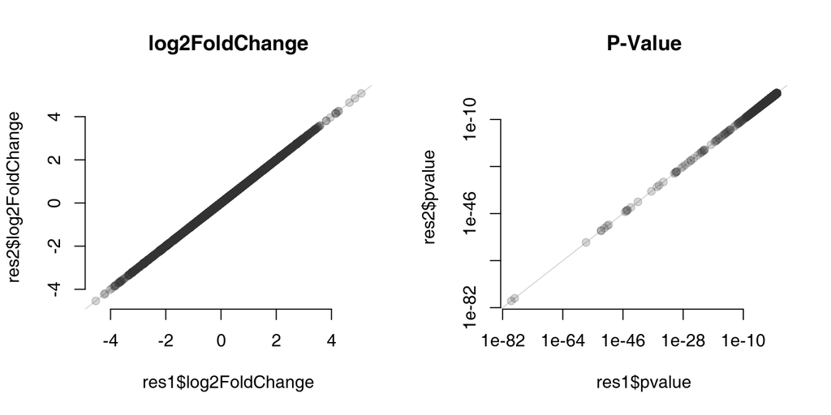

## Complex case again

So what happens if we use the same approach with intercept for the large data set?

```r
## we can change the design on the fly
design(ds) <- ~ group
ds <- DESeq(ds)
resultsNames(ds)
```

```
## [1] "Intercept"                       "group_A549.IAV.mock_vs_A549.IAV"
## [3] "group_A549.mock_vs_A549.IAV"     "group_A549.RSV_vs_A549.IAV"
## [5] "group_A549.RSV.mock_vs_A549.IAV" "group_A549.SC2V_vs_A549.IAV"
## [7] "group_NHBE.mock_vs_A549.IAV"     "group_NHBE.SC2V_vs_A549.IAV"
```

```r
res4 <- results(ds, contrast=c(rep(0, 6), -1, 1))
```

We have the direct comparisons, but unfortunately they are always relative to the same group, and we are not necessarily interested in that (why compare NHBE Sars-Cov-2 to A549 Influenza?). Thus, we need to define contrasts anyway to get the results. We ignore the first six coefficients (`rep(0, 6)`) and calculate the difference between the remaining two.

## Do we have the same results?

We do not have *identical* results as in the smaller data set, since the dispersion estimates are based on a larger data set and, consequently, slightly different from the small data set.

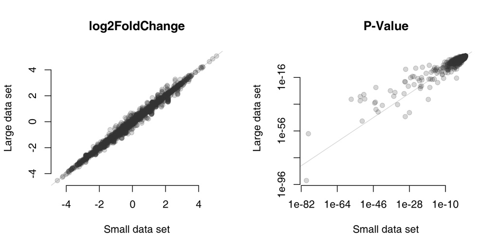